# Gobike Dataset Exploration Slides

## by Muneaki Umino

## Investigation Overview

My goal for this presentation is to introduce my findings of Gobike dataset with you, and shere my excitement of the power of visualizations.

## Dataset Overview

I used **Ford Gobike Tripdata(2017)** available on https://s3.amazonaws.com/baywheels-data/index.html \ The dataset contains **519,700** rows of observations of:

**1.How long customers use Gobike service,**

**2.Where they start, and finish their Gobike experiences,**

**3.User type (customer or subscriber)**

I also added columns to show:

**1.What day customers use Gobike service,**

**2.Distance of each Gobike travels**

## Univariate Exploration

I made some visualization of single columns to see their characterestics.

I tried to find trends of;

**1.Driving duration**

**2.Travel distance**

**3.Difference between days**

**4.Difference between weekdays and weekends**

**5.difference between user types**

## 1.Driving Duration

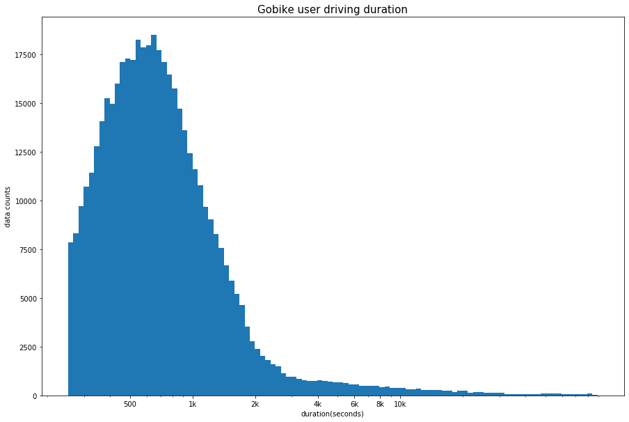

```python
log_binsize = 0.025
bins = 10 ** np.arange(2.4, np.log10(df['duration_sec'].max())+log_binsize, log_binsize)

plt.figure(figsize=[15, 10])
plt.hist(data = df, x = 'duration_sec', bins = bins)
plt.xscale('log')
plt.xticks([500, 1000, 2000, 4000, 6000, 8000, 10000], ['500', '1k', '2k', '4k', '6k', '8k', '10k'], fontsize = 10)

plt.xlabel('duration(seconds)', fontsize = 10)
plt.ylabel('data counts', fontsize = 10)
plt.title('Gobike user driving duration', fontsize = 15)
plt.show()
```

## 2.Travel distance

Gobikers driving distance are short. It is around **1.5km**, which is **1 miles**.

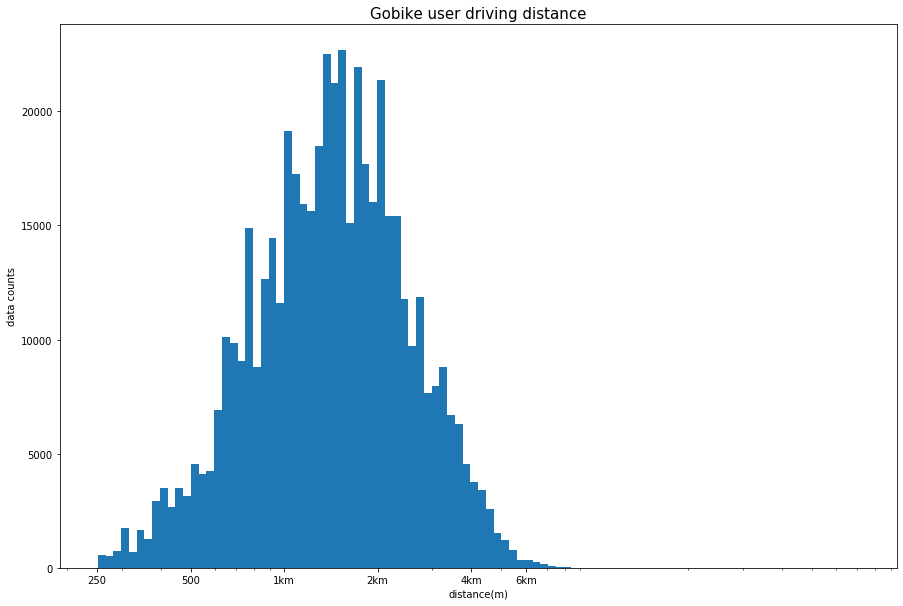

```python
log_binsize = 0.025
bins = 10 ** np.arange(2.4, np.log10(df['distance'].max())+log_binsize, log_binsize)

plt.figure(figsize=[15, 10])
plt.hist(data = df, x = 'distance', bins = bins)
plt.xscale('log')
plt.xticks([250, 500, 1000, 2000, 4000, 6000], ['250', '500', '1km', '2km', '4km', '6km'])

plt.xlabel('distance(m)', fontsize = 10)
plt.ylabel('data counts', fontsize = 10)
plt.title('Gobike user driving distance', fontsize = 15)
plt.show()
```

## 3.Difference between days

There is a big difference, I can clearly see there are **more Gobikers on weekdays.** that means they probably use Gobike for **commute to work on weekdays than sightseeing on weekends.**

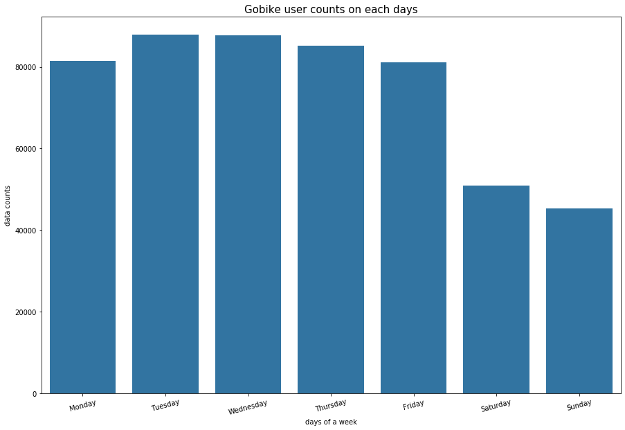

```python
level_order = ['Monday','Tuesday','Wednesday','Thursday', 'Friday', 'Saturday', 'Sunday']
category_order = pd.api.types.CategoricalDtype(ordered = True, categories = level_order)
df['day'] = df['day'].astype(category_order)

plt.figure(figsize=[15, 10])
base_color = sb.color_palette()[0]
sb.countplot(data = df, x = 'day', color = base_color)

plt.xticks(rotation = 15)
plt.xlabel('days of a week', fontsize = 10)
plt.ylabel('data counts', fontsize = 10)
plt.title('Gobike user counts on each days', fontsize = 15);
```

## 4.Difference between weekdays and weekends

Seeing weekday users and weekend users show much **obvious difference**

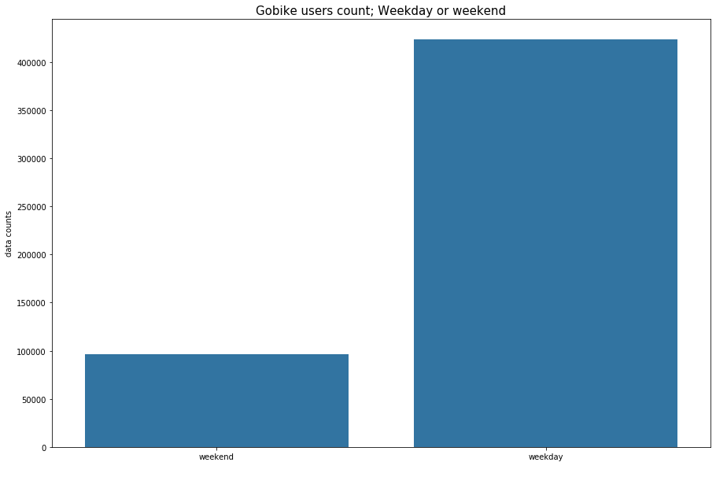

```python
base_color = sb.color_palette()[0]
plt.figure(figsize=[15, 10])
sb.countplot(data = df , x = 'weekday', color = base_color)



plt.xlabel(' ', fontsize = 10)
plt.ylabel('data counts', fontsize = 10)
plt.title('Gobike users count; Weekday or weekend', fontsize = 15);
```

## 5.difference between user types

There are **more Subscribers**, means there are more people use Gobike regularly. Probbaly those subscribers are **commuters** because this gragh is **almost identical**\ to the weekend users and weekday users graph.

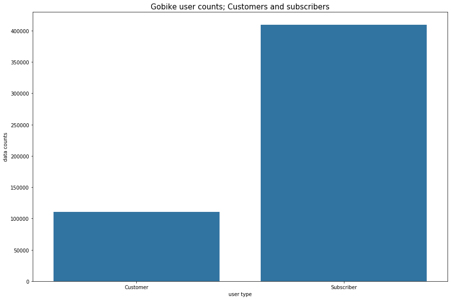

```python
base_color = sb.color_palette()[0]
plt.figure(figsize=[15, 10])
sb.countplot(data = df , x = 'user_type', color = base_color)

plt.xlabel('user type', fontsize = 10)
plt.ylabel('data counts', fontsize = 10)
plt.title('Gobike user counts; Customers and subscribers', fontsize = 15);
```

## Bivariate Exploration

There was clear difference in **duration, distance, each days, or user type.** Now let's **convine each aspects** to find more informations from this database.

## 1.Distance vs. Duration

Most customers use Gobike up tp **1500 seconds (25min) and 4000m (2.5mile).** This data indicates customers use Gobike for **short and quick trip.**

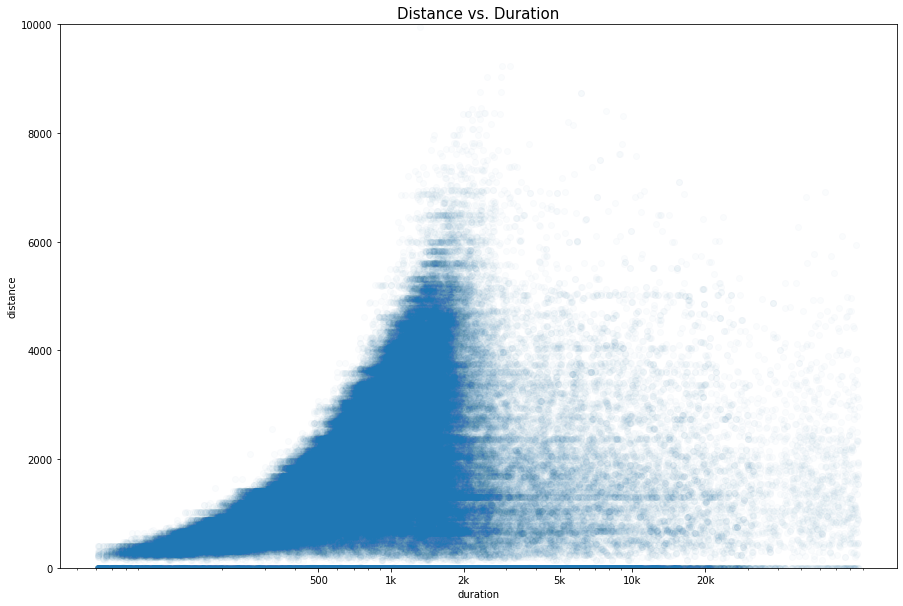

```python
plt.figure(figsize = [15, 10])
plt.scatter(data = df, x = 'duration_sec', y = 'distance', alpha = 1/50)

plt.xscale('log')
plt.xticks([500, 1e3, 2e3, 5e3, 1e4, 2e4], [500, '1k', '2k', '5k', '10k', '20k'])
plt.xlabel('duration', fontsize = 10)
plt.ylabel('distance', fontsize = 10)
plt.title('Distance vs. Duration', fontsize = 15)
plt.ylim(0,10000)
plt.show()
```

## 2. Distance, Duratiom vs. Day

For distance, customers drive distance are almost same for all week. But there is a clear difference between weekday and weekend customers when you look at duration. That means customers use Gobike from Monday to friday have specific destinations. Customers use Gobike on weekends look like they are wondering around the city.

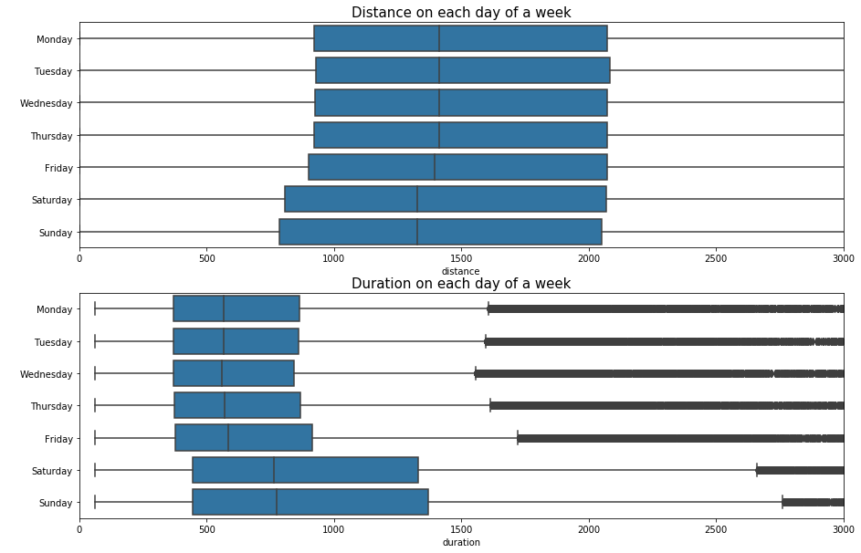

```python
plt.figure(figsize = [15, 10])

plt.subplot(2, 1, 1)

base_color = sb.color_palette()[0]
sb.boxplot(data = df, x = 'distance', y = 'day', color = base_color)
plt.xlabel('distance', fontsize = 10)
plt.ylabel(' ', fontsize = 10)
plt.title('Distance on each day of a week', fontsize = 15)
plt.xlim(0, 3000)

plt.subplot(2, 1, 2)

sb.boxplot(data = df, x = 'duration_sec', y = 'day', color = base_color)
plt.xlabel('duration', fontsize = 10)
plt.ylabel(' ', fontsize = 10)
plt.title('Duration on each day of a week', fontsize = 15)
plt.xlim(0, 3000);
```

## 3. Distance, Duration vs. Weekday

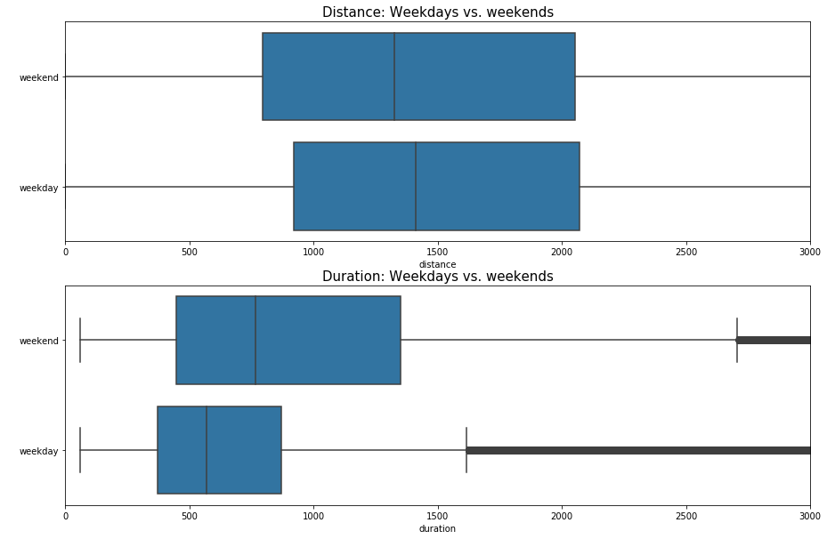

```python
plt.figure(figsize = [15, 10])

plt.subplot(2, 1, 1)

base_color = sb.color_palette()[0]
sb.boxplot(data = df, x = 'distance', y = 'weekday', color = base_color)
plt.xlabel('distance', fontsize = 10)
plt.ylabel(' ', fontsize = 10)
plt.title('Distance: Weekdays vs. weekends', fontsize = 15)
plt.xlim(0, 3000)

plt.subplot(2, 1, 2)

sb.boxplot(data = df, x = 'duration_sec', y = 'weekday', color = base_color)
plt.xlabel('duration', fontsize = 10)
plt.ylabel(' ', fontsize = 10)
plt.title('Duration: Weekdays vs. weekends', fontsize = 15)
plt.xlim(0, 3000);
```

## 4. Distance, Duration vs. User_type

When you look at duration and distance with user_type, the difference is more obvious. **Subscriber drive shorter distance, and much quicker.**

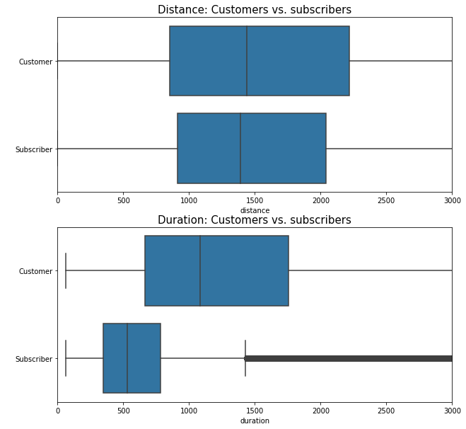

```python
plt.figure(figsize = [10, 10])

plt.subplot(2, 1, 1)

base_color = sb.color_palette()[0]
sb.boxplot(data = df, x = 'distance', y = 'user_type', color = base_color)
plt.xlabel('distance', fontsize = 10)
plt.ylabel(' ', fontsize = 10)
plt.title('Distance: Customers vs. subscribers', fontsize = 15)
plt.xlim(0, 3000)

plt.subplot(2, 1, 2)

sb.boxplot(data = df, x = 'duration_sec', y = 'user_type', color = base_color)
plt.xlabel('duration', fontsize = 10)
plt.ylabel(' ', fontsize = 10)
plt.title('Duration: Customers vs. subscribers', fontsize = 15)
plt.xlim(0, 3000);
```

## 5. Relationship between categorical values

By looking at this result,you should be confident to say there are **customers use Gobike to commute their workplace on weekdays.** They subscribe Gobike to commute, that's why there are **more users on weekdays.**

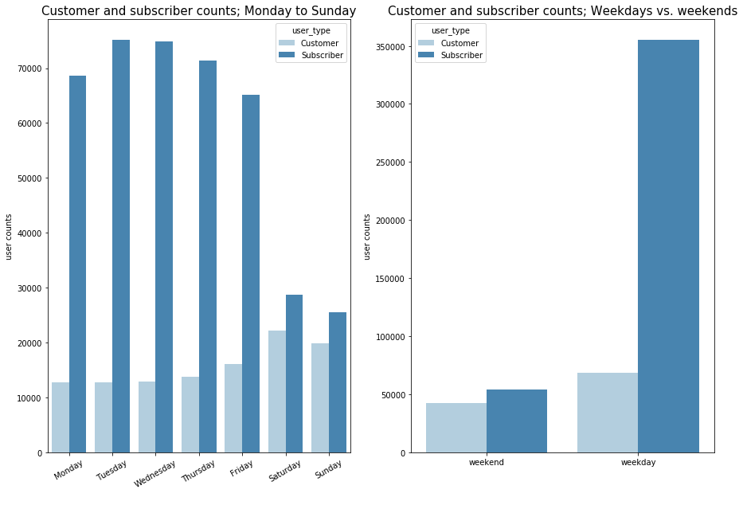

```python
plt.figure(figsize = [15, 10])
plt.subplot(1,2,1)
sb.countplot(data = df, x = 'day', hue = 'user_type', palette = 'Blues')
plt.xlabel(' ', fontsize = 10)
plt.ylabel('user counts', fontsize = 10)
plt.title('Customer and subscriber counts; Monday to Sunday', fontsize = 15)
plt.xticks(rotation = 30)

plt.subplot(1,2,2)
sb.countplot(data = df, x = 'weekday', hue = 'user_type', palette = 'Blues')
plt.xlabel(' ', fontsize = 10)
plt.ylabel('user counts', fontsize = 10)
plt.title('Customer and subscriber counts; Weekdays vs. weekends', fontsize = 15);
```

## Multivariate Exploration

Let's explore the database **deeper** to see how the **three categorical measures** play into the relationship between duration and distance.

The plot on the left describes **subscriber spend much less time than customer.** Also, the plot on the right indicates **travel distances are longer on Monday to Friday for both customer and subscriber** because they use Gobike for commute. Now it is obvious that **subscriber know where they want to go**, and they are using Gobike service to commute specific locations(stations, companies or schools).

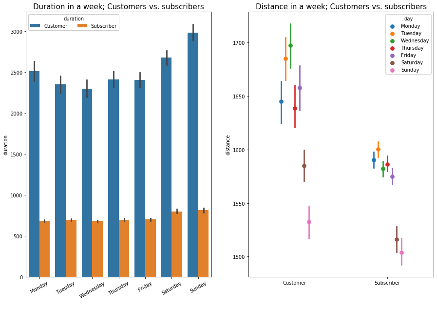

```python
plt.figure(figsize = [15, 10])

plt.subplot(1, 2, 1)
ax = sb.barplot(data = df, x = 'day', y = 'duration_sec', hue = 'user_type')
ax.legend(loc = 2, ncol = 3, framealpha = 1, title = 'duration')
plt.xlabel(' ', fontsize = 10)
plt.ylabel('duration', fontsize = 10)
plt.title('Duration in a week; Customers vs. subscribers', fontsize = 15)
plt.xticks(rotation = 30)

plt.subplot(1, 2, 2)
ax = sb.pointplot(data = df, x = 'user_type', y = 'distance', hue = 'day',
                  dodge = 0.3, linestyles = "")
plt.xlabel(' ', fontsize = 10)
plt.ylabel('distance', fontsize = 10)
plt.title('Distance in a week; Customers vs. subscribers', fontsize = 15);
```